# 04-rmd-global-opts-device

Your Name

2017/06/27

```r
knitr::opts_chunk$set(fig.width = 4,
                      fig.height = 5,
                      dev = c("png", "pdf", "tiff"))
```

# Tasks

- set a global option to:
- hide all of the code
  - hint: put `knitr::opts_chunk$set()` in a chunk and set the options
- set the graphics device
  - hint: `dev = "png"` or even `dev = c("png", "pdf","tiff")`
- set the DPI
  - hint: `dpi = 300`

# Introduction

This is a simple analysis of the New York Air Quality Measurements using the R statistical programming language. As stated in the helpfile `?airquality`, this dataset contains:

> Daily air quality measurements in New York, May to September 1973.

And the dataset is sourced from:

> … the New York State Department of Conservation (ozone data) and the National Weather Service (meteorological data).

It contains the following variables

- Ozone: Mean ozone in parts per billion from 1300 to 1500 hours at Roosevelt Island.
- Solar.R: Solar radiation in Langleys in the frequency band 4000–7700 Angstroms from 0800 to 1200 hours at Central Park.
- Wind: Average wind speed in miles per hour at 0700 and 1000 hours at LaGuardia Airport.
- Temp: Maximum daily temperature in degrees Fahrenheit at La Guardia Airport.
- Month: Month (1–12)
- Day: Day of month (1–31)

# Method

```r
lm_fit <- lm(Ozone ~ Solar.R + Temp + Wind,
             data = airquality)
```

$$Ozone \sim \beta_0 + \beta_1Solar.R + \beta_2 Wind + \beta_3Temp + \epsilon$$

# Results

We can see that there is an interesting relationship between ozone and solar radiation in figure 1 below, plotted using ggplot2.

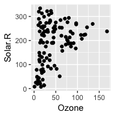

```r
library(ggplot2)
ggplot(airquality,
       aes(x = Ozone,
           y = Solar.R)) +
  geom_point()
```

We can also see that there is an interesting relationship between Ozone and temperature.

[figure not shown]

```r
knitr::kable(coef(lm_fit))
```

| (Intercept) | -64.3420789 |
| --- | --- |
| Solar.R | 0.0598206 |
| Temp | 1.6520929 |
| Wind | -3.3335913 |